# covid19 slides

## Coronavirus (COVID-19)

```
Updated on 19-January-2022
```

**Datasets:**

- **Confirmed cases**, raw data [here](https://raw.githubusercontent.com/CSSEGISandData/COVID-19/master/csse_covid_19_data/csse_covid_19_time_series/time_series_covid19_confirmed_global.csv) and **Latest cases**, raw data [here](https://raw.githubusercontent.com/CSSEGISandData/COVID-19/master/csse_covid_19_data/csse_covid_19_daily_reports/01-02-2021.csv)
- **Covid19 open data**: comprehensive data inc. vaccinations, hospitalisations. See [here](https://github.com/GoogleCloudPlatform/covid-19-open-data#aggregated-table)

**Sources:**

- [Johns Hopkins University](https://github.com/CSSEGISandData/COVID-19). Field definition: [Link here](https://github.com/CSSEGISandData/COVID-19/tree/master/csse_covid_19_data)
- [Covid19 Open data](https://open-covid-19.github.io/explorer/#main-table) and associated [Github](https://github.com/GoogleCloudPlatform/covid-19-open-data#covid-19-open-data) by Googlecloud
- [Santé publique France](https://www.data.gouv.fr/fr/datasets/indicateurs-de-lactivite-epidemique-taux-dincidence-de-lepidemie-de-covid-19-par-metropole/#resources) - French National Health Agency

**Data processing:** automation, data wrangling, exportable to Excel

# Latest Data (John Hopkins) - what the data Looks like

| Province_State | FIPS | Admin2 | Country_Region | Last_Update | Lat | Long_ | Confirmed | Deaths | Recovered | Active | Combined_Key | Incident_Rate | Case_Fatality_Ratio |
| --- | --- | --- | --- | --- | --- | --- | --- | --- | --- | --- | --- | --- | --- |
| Australian Capital Territory | NaN | NaN | Australia | 2022-01-19 04:21:23 | -35.4735 | 149.0124 | 27618 | 20 | NaN | NaN | Australian Capital Territory, Australia | 6451.296426 | 0.072417 |
| New South Wales | NaN | NaN | Australia | 2022-01-19 04:21:23 | -33.8688 | 151.2093 | 864817 | 951 | NaN | NaN | New South Wales, Australia | 10653.079576 | 0.109965 |
| Northern Territory | NaN | NaN | Australia | 2022-01-19 04:21:23 | -12.4634 | 130.8456 | 7318 | 2 | NaN | NaN | Northern Territory, Australia | 2979.641694 | 0.027330 |
| Queensland | NaN | NaN | Australia | 2022-01-19 04:21:23 | -27.4698 | 153.0251 | 265565 | 63 | NaN | NaN | Queensland, Australia | 5191.379142 | 0.023723 |
| South Australia | NaN | NaN | Australia | 2022-01-19 04:21:23 | -34.9285 | 138.6007 | 81783 | 50 | NaN | NaN | South Australia, Australia | 4656.020495 | 0.061137 |
| Tasmania | NaN | NaN | Australia | 2022-01-19 04:21:23 | -42.8821 | 147.3272 | 21546 | 13 | NaN | NaN | Tasmania, Australia | 4023.529412 | 0.060336 |
| Victoria | NaN | NaN | Australia | 2022-01-19 04:21:23 | -37.8136 | 144.9631 | 685007 | 1735 | NaN | NaN | Victoria, Australia | 10332.086457 | 0.253282 |
| Western Australia | NaN | NaN | Australia | 2022-01-19 04:21:23 | -31.9505 | 115.8605 | 1323 | 9 | NaN | NaN | Western Australia, Australia | 50.292709 | 0.680272 |

Field definition: [Link here](https://github.com/CSSEGISandData/COVID-19/tree/master/csse_covid_19_data)  
**Note**: "Confirmed" is the latest cumulative case count

# Latest data (John Hopkins) - summarising data by country and recalculating metrics (Population, %Infected, Mortality, Fatality)

| Country_Region | Population | Confirmed | Deaths | Recovered | Active | %pop_infected | Mortality | Fatality |
| --- | --- | --- | --- | --- | --- | --- | --- | --- |
| China | 1.404676e+09 | 118297 | 4849 | 0.0 | 0.0 | 0.000084 | 0.000003 | 0.040990 |
| India | 1.371337e+09 | 37901241 | 487202 | 0.0 | 0.0 | 0.027638 | 0.000355 | 0.012855 |
| US | 3.323046e+08 | 67589830 | 853955 | 0.0 | 0.0 | 0.203397 | 0.002570 | 0.012634 |
| Indonesia | 2.735236e+08 | 4273783 | 144183 | 0.0 | 0.0 | 0.015625 | 0.000527 | 0.033737 |
| Brazil | 2.101471e+08 | 23229851 | 621803 | 0.0 | 0.0 | 0.110541 | 0.002959 | 0.026767 |
| Pakistan | 2.078318e+08 | 1338993 | 29037 | 0.0 | 0.0 | 0.006443 | 0.000140 | 0.021686 |
| Nigeria | 2.061396e+08 | 251341 | 3116 | 0.0 | 0.0 | 0.001219 | 0.000015 | 0.012397 |
| Bangladesh | 1.646894e+08 | 1632794 | 28164 | 0.0 | 0.0 | 0.009914 | 0.000171 | 0.017249 |
| Russia | 1.466447e+08 | 10682826 | 316168 | 0.0 | 0.0 | 0.072848 | 0.002156 | 0.029596 |
| Mexico | 1.277923e+08 | 4385415 | 301469 | 0.0 | 0.0 | 0.034317 | 0.002359 | 0.068744 |
| Japan | 1.261669e+08 | 1934391 | 18443 | 0.0 | 0.0 | 0.015332 | 0.000146 | 0.009534 |
| Ethiopia | 1.149636e+08 | 459486 | 7184 | 0.0 | 0.0 | 0.003997 | 0.000062 | 0.015635 |
| Philippines | 1.095811e+08 | 3270758 | 52962 | 0.0 | 0.0 | 0.029848 | 0.000483 | 0.016193 |
| Egypt | 1.023344e+08 | 402611 | 22205 | 0.0 | 0.0 | 0.003934 | 0.000217 | 0.055152 |
| Vietnam | 9.733858e+07 | 2062128 | 35972 | 0.0 | 0.0 | 0.021185 | 0.000370 | 0.017444 |
| Congo (Kinshasa) | 8.956140e+07 | 82984 | 1278 | 0.0 | 0.0 | 0.000927 | 0.000014 | 0.015401 |
| Turkey | 8.433907e+07 | 10593687 | 85077 | 0.0 | 0.0 | 0.125608 | 0.001009 | 0.008031 |
| Iran | 8.399295e+07 | 6227849 | 132113 | 0.0 | 0.0 | 0.074147 | 0.001573 | 0.021213 |
| Germany | 8.301921e+07 | 8222262 | 116085 | 0.0 | 0.0 | 0.099040 | 0.001398 | 0.014118 |
| Thailand | 6.979998e+07 | 2308615 | 21898 | 0.0 | 0.0 | 0.033075 | 0.000314 | 0.009485 |

# Death toll for top-20 most populated countries

Sorted by population in descending order  
Vertical green line is average  
Vertical orange line is median

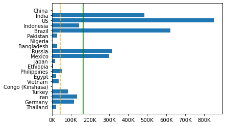

# Bubble chart: % Infected population,Fatality, Death toll

- **x axis** = %population infected (cumulative cases/population), approximation
- **y axis** = Fatality rate (total deaths/total cases) | **bubble size** = # deaths

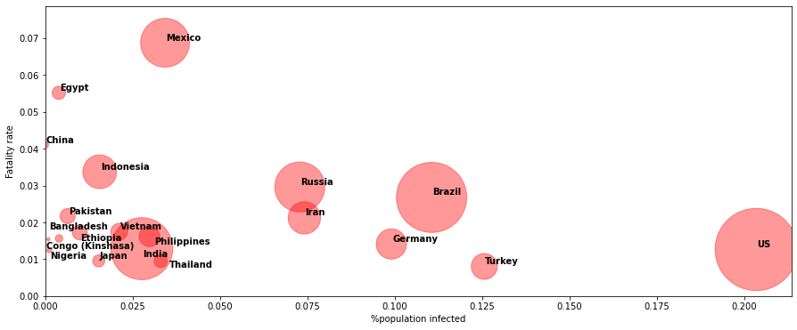

### Comments

- % population infected (approximation only as this does not consider the fact that reinfected people inflate confirmed cases): impacted by testing policy (number of test centres, free or paid tests, test kit avaibility etc); and by willingness of countries to report accurate case numbers
- Fatality rate: impacted by vaccination rate, hospital capacity/equipment; and by willingness of countries to report accurate case numbers and death toll
- Deaths: this should be analysed concurrently with population size

# Comparative Analysis on key indicators - covid19 open data (google-cloud)

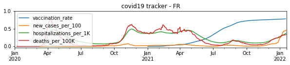

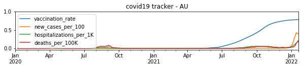

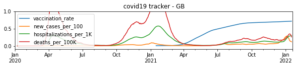

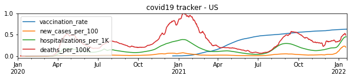

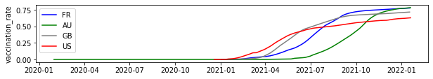

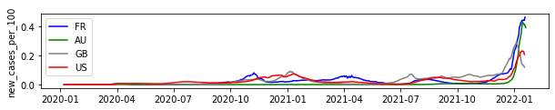

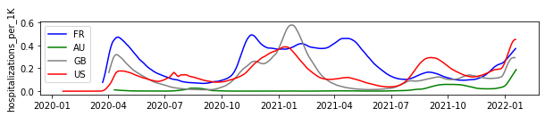

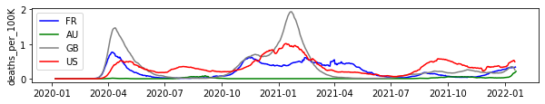

# The case of France

- New cases
- Incidence rate (New cases/population * 100 000)

[figure not shown]

# Confirmed cases (John Hopkins) - what the data looks like

|  | Province/State | Country/Region | Lat | Long | 1/22/20 | 1/23/20 | 1/24/20 | 1/25/20 | 1/26/20 | 1/27/20 | ... | 1/9/22 | 1/10/22 | 1/11/22 | 1/12/22 | 1/13/22 | 1/14/22 | 1/15/22 | 1/16/22 | 1/17/22 | 1/18/22 |
| --- | --- | --- | --- | --- | --- | --- | --- | --- | --- | --- | --- | --- | --- | --- | --- | --- | --- | --- | --- | --- | --- |
| 130 | Other | France | 46.2276 | 2.2137 | 0 | 0 | 2 | 3 | 3 | 3 | ... | 11875607 | 11963184 | 12322734 | 12655210 | 12956857 | 13279505 | 13604085 | 13869172 | 13869172 | 13865920 |

1 rows × 732 columns

# Confirmed cases (John Hopkins) - Pivoting the data

- **Data wrangling**: dates are pivoted in such a way that they are now a dimension (as opposed to columns before)
- **New calculation**: number of new cases is added

|  | Province/State | Country/Region | Lat | Long | Date | Cases | Newcases |
| --- | --- | --- | --- | --- | --- | --- | --- |
| 84448 | Other | France | 46.2276 | 2.2137 | 2020-01-22 | 0 | 0.0 |
| 84449 | Other | France | 46.2276 | 2.2137 | 2020-01-23 | 0 | 0.0 |
| 84450 | Other | France | 46.2276 | 2.2137 | 2020-01-24 | 2 | 2.0 |
| 84451 | Other | France | 46.2276 | 2.2137 | 2020-01-25 | 3 | 1.0 |
| 84452 | Other | France | 46.2276 | 2.2137 | 2020-01-26 | 3 | 0.0 |
| ... | ... | ... | ... | ... | ... | ... | ... |
| 85171 | Other | France | 46.2276 | 2.2137 | 2022-01-14 | 13279505 | 322648.0 |
| 85172 | Other | France | 46.2276 | 2.2137 | 2022-01-15 | 13604085 | 324580.0 |
| 85173 | Other | France | 46.2276 | 2.2137 | 2022-01-16 | 13869172 | 265087.0 |
| 85174 | Other | France | 46.2276 | 2.2137 | 2022-01-17 | 13869172 | 0.0 |
| 85175 | Other | France | 46.2276 | 2.2137 | 2022-01-18 | 13865920 | -3252.0 |

728 rows × 7 columns

**Notes**  
Cases: means cumulative cases  
New cases: means new daily cases (the delta between Cases on a given day and Cases on the day before)

# France - New cases (John Hopkins)

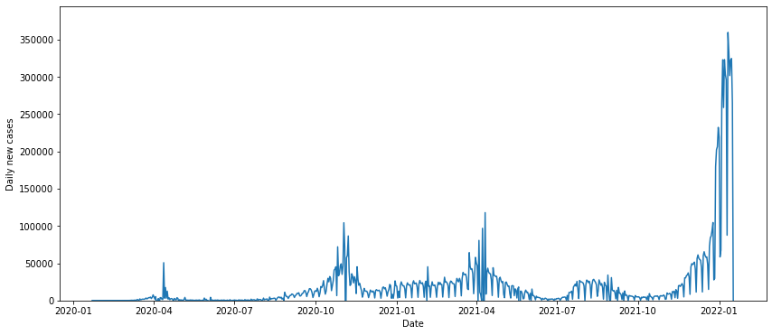

**Note**: 5 waves: Apr20, Oct20, Apr21, Aug21, Dec21

# France: incidence rate - validating covid19 open data (Google Cloud)

### Checking incidence rate: googlecloud (incidence_std) with DataGouv/Sante France Publique - i.e. France's health national agency (incidence rate)

Incidence defined as: (100000 * daily new cases) / Population

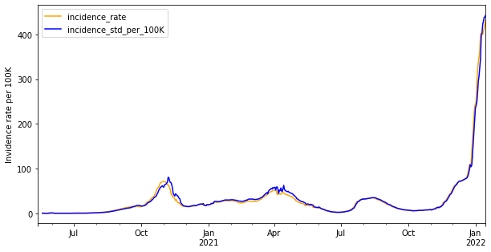

validated!

### France: checking daily new cases - Googlecloud (new_confirmed) vs. John Hopkins (Newcases)

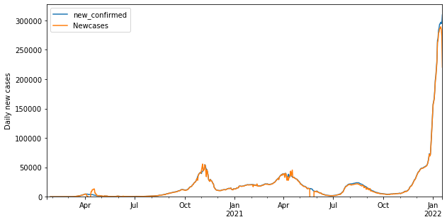

*validated*!